# Group 14 Members:

# Insight:

# Air pollutants across Time and Boroughs

# Nitrogen dioxide (NO2)

```python
#To extract records for Nitrogen dioxide
NO2 = annual_avg_pol[annual_avg_pol['Name']=='Nitrogen dioxide (NO2)']
#NO2
```

```
No artists with labels found to put in legend.  Note that artists whose label start with an underscore are ignored when legend() is called with no argument.
```

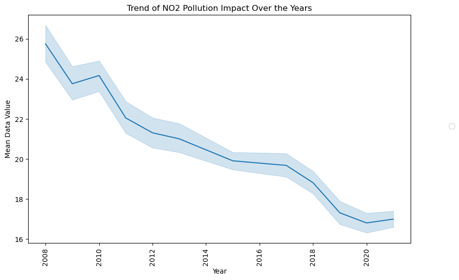

```python
#Plotting a line chart to show the trend of  NO2  distribution over the years
plt.figure(figsize=(10, 6))
sns.lineplot(x='Start_year', y='Data Value', data=NO2)
plt.title('Trend of NO2 Pollution Impact Over the Years')
plt.xlabel('Year')
plt.ylabel('Mean Data Value')
plt.xticks(rotation=90)
plt.legend(loc=(1.1,0.5))
plt.tight_layout
plt.show()
```

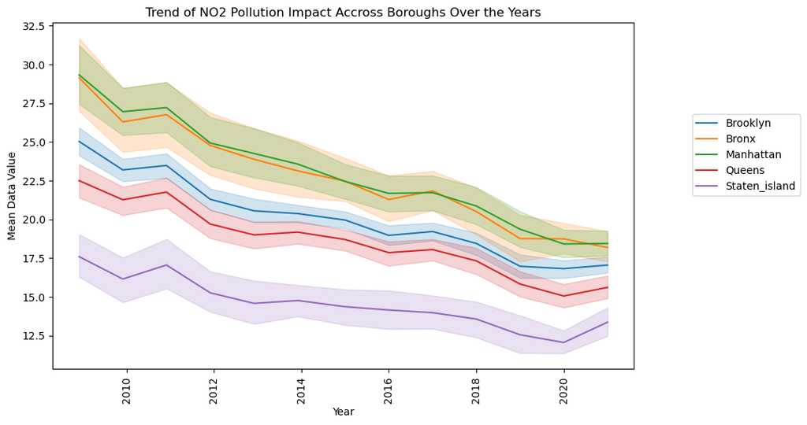

```python
#Checking the trend of NO2 Impact accross Boroughs
plt.figure(figsize=(10, 6))
sns.lineplot(x='Start_Date', y='Data Value', hue='Borough_name', data=NO2)
plt.title('Trend of NO2 Pollution Impact Accross Boroughs Over the Years')
plt.xlabel('Year')
plt.ylabel('Mean Data Value')
plt.xticks(rotation=90)
plt.legend(loc=(1.1,0.5))
plt.tight_layout
plt.show()
```

# Insights:

The trend of NO2 pollution impact over the years accross all boroughs shows a steady decline in the impact of this pollutant over the years until 2020 when the Covid-19 caused a spike in the effect of the boroughs except Bronx borough which kept declining in New York geographical area.

# Fine particles (PM 2.5)

```python
# Getting the record of Fine particles from Name
Fine_part = annual_avg_pol[annual_avg_pol['Name']=='Fine particles (PM 2.5)']
```

```
No artists with labels found to put in legend.  Note that artists whose label start with an underscore are ignored when legend() is called with no argument.
```

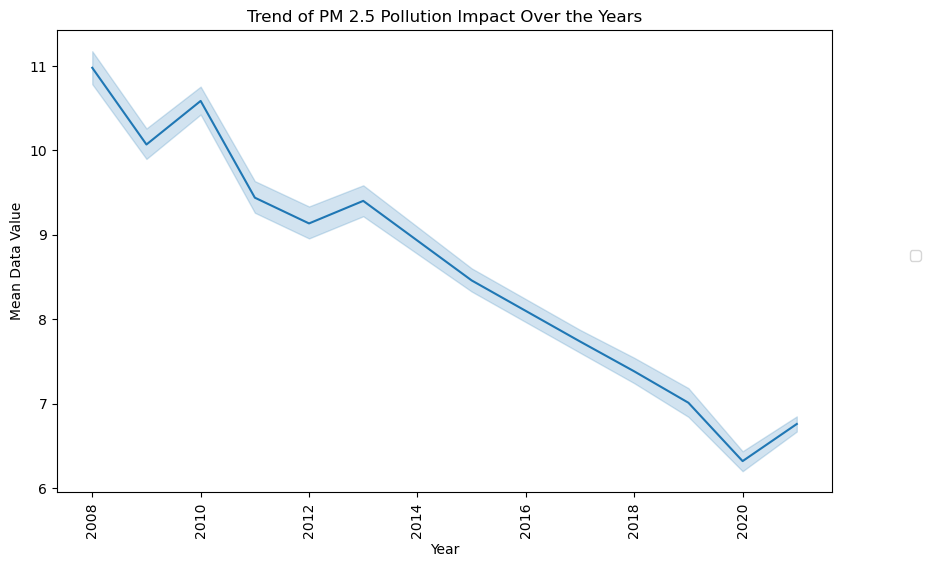

```python
#Plotting a line chart to show the trend of  PM 2.5  distribution over the years
plt.figure(figsize=(10, 6))
sns.lineplot(x='Start_year', y='Data Value', data=Fine_part)
plt.title('Trend of PM 2.5 Pollution Impact Over the Years')
plt.xlabel('Year')
plt.ylabel('Mean Data Value')
plt.xticks(rotation=90)
plt.legend(loc=(1.1,0.5))
plt.tight_layout
plt.show()
```

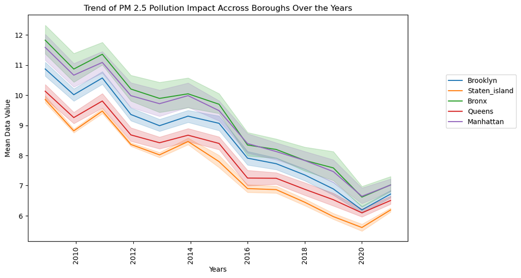

```python
#Checking the trend of PM 2.5 Impact accross Boroughs
plt.figure(figsize=(10, 6))
sns.lineplot(x='Start_Date', y='Data Value', hue='Borough_name', data=Fine_part)
plt.title('Trend of PM 2.5 Pollution Impact Accross Boroughs Over the Years')
plt.xlabel('Years')
plt.ylabel('Mean Data Value')
plt.xticks(rotation=90)
plt.legend(loc=(1.1,0.5))
plt.tight_layout
plt.show()
```

# Insights:

The trend of PM 2.5 pollution impact over the years accross all boroughs shows a steady decline in the impact of this pollutant over the years until in 2020 when the Covid-19 caused a spike in the effect accross the boroughs in New York geographical area.

# Ozone (O3)

```python
seasons = df[df['Time Period'].str.contains('|'.join(keywords))]
```

```python
#Getting the record of ozone from sheet
Ozone = seasons[seasons['Name']=='Ozone (O3)']
#Ozone
```

```
No artists with labels found to put in legend.  Note that artists whose label start with an underscore are ignored when legend() is called with no argument.
```

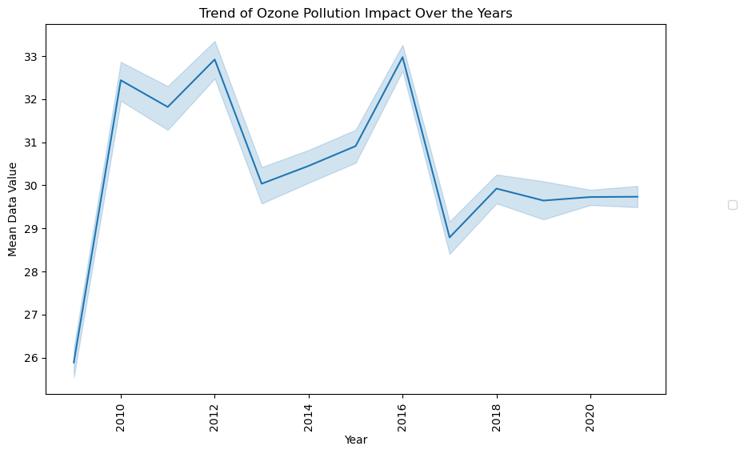

```python
##Plotting a line chart to show the trend of  PM 2.5  distribution over the years
plt.figure(figsize=(10, 6))
sns.lineplot(x='Start_year', y='Data Value', data=Ozone)
plt.title('Trend of Ozone Pollution Impact Over the Years')
plt.xlabel('Year')
plt.ylabel('Mean Data Value')
plt.xticks(rotation=90)
plt.legend(loc=(1.1,0.5))
plt.tight_layout
plt.show()
```

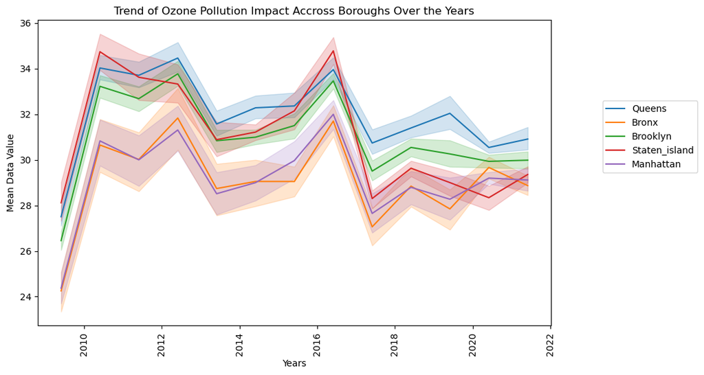

```python
#Checking the trend of Ozone (O3) Impact accross Boroughs
plt.figure(figsize=(10, 6))
sns.lineplot(x='Start_Date', y='Data Value', hue='Borough_name', data=Ozone)
plt.title('Trend of Ozone Pollution Impact Accross Boroughs Over the Years')
plt.xlabel('Years')
plt.ylabel('Mean Data Value')
plt.xticks(rotation=90)
plt.legend(loc=(1.1,0.5))
plt.tight_layout
plt.show()
```

# Insight:

The trend of Ozone pollution impact over the years accross all boroughs shows that ozone witness a rise in value from 2009 which then have been ranging between the mean data value range of 28-34 since then in New York geographical area.

# Health Impact accross time

```python
#Getting the impacts from name column
impacts = ['Asthma emergency department visits due to PM2.5',
'Asthma hospitalizations due to Ozone',
'Respiratory hospitalizations due to PM2.5 (age 20+)',
'Cardiovascular hospitalizations due to PM2.5 (age 40+)',
'Cardiac and respiratory deaths due to Ozone',
'Asthma emergency departments visits due to Ozone',
'Deaths due to PM2.5']

annual_avg_impact = annual_avg[annual_avg['Name'].isin(impacts)]
#annual_avg_impact
```

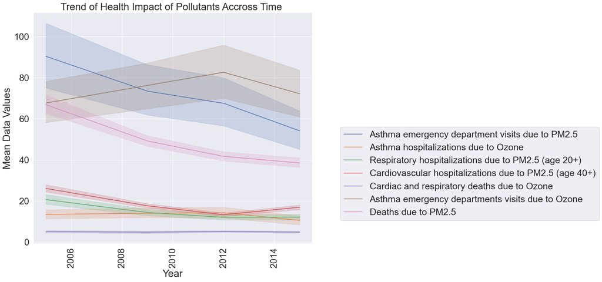

```python
#Plotting several health impact accross time
plt.figure(figsize=(12, 10))
sns.lineplot(x='Start_Date', y='Data Value', hue='Name', data=annual_avg_impact)
plt.title('Trend of Health Impact of Pollutants Accross Time ')
plt.xlabel('Year')
plt.ylabel('Mean Data Values')
plt.xticks(rotation=90)
plt.legend(loc=(1.1,0.1))
plt.tight_layout
plt.show()
```

# Insights:

This trend of health impact of pollutant in New York geographical area over the years shows that:

Asthma emergency department visit due to PM 2.5, Death due to PM 2.5 and Respiratory hospitalization due to PM 2.5 (AGE 20+) has been on steady decline over the years.

Asthma emergency department visit due to Ozone and Asthma hospitalization due to Ozone has been on the rise since 2005 but witness steady decline from 2012 showing that there has been ways to control these effects since 2012.

Finally, Cardivascular hospitalizations due to PM 2.5 (40+) has been on steady decline frfom 2005 till 2012 when a rise in the number has been witnessed through 2015.

# Asthma emergency department visits due to PM2.5

```python
Asthma_emerg_fine = annual_avg_impact[annual_avg_impact['Name']=='Asthma emergency department visits due to PM2.5']
#Asthma_emerg_fine.head()
```

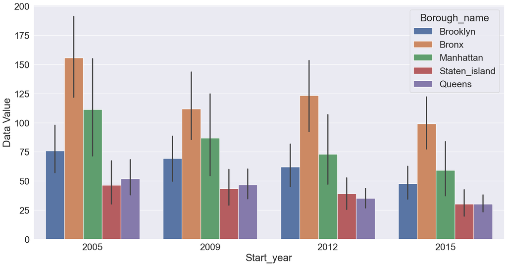

```python
#Plotting chart showing the asthma visit due to PM2.5 accross borough
plt.figure(figsize=(20,10))
sns.set(font_scale=2)
sns.barplot(x='Start_year', y='Data Value',hue = "Borough_name",  data=Asthma_emerg_fine)
plt.xticks(rotation=0)
plt.show;
```

# Insight:

This trend of Asthma emergency visit due to pm2.5 in New York geographical boroughs over the years shows that Bronx borough has the highest number of visit while Queens and Staten_Island has the lowest number of hospital visit due to PM2.5.

# Asthma hospitalizations due to Ozone

```python
#Getting the avg impact of ozone on hospitalization of asthma patients
Asthma_hos_ozone = annual_avg_impact[annual_avg_impact['Name']=='Asthma hospitalizations due to Ozone']
#Asthma_hos_ozone.head()
```

```python
ast = Asthma_hos_ozone.groupby(['Name', 'Borough_name','Start_year'])['Data Value'].sum().sort_values(ascending=False).reset_index()
ast
```

|  | Name | Borough_name | Start_year | Data Value |
| --- | --- | --- | --- | --- |
| 0 | Asthma hospitalizations due to Ozone | Bronx | 2012 | 485.8 |
| 1 | Asthma hospitalizations due to Ozone | Bronx | 2009 | 429.6 |
| 2 | Asthma hospitalizations due to Ozone | Bronx | 2005 | 390.3 |
| 3 | Asthma hospitalizations due to Ozone | Bronx | 2015 | 358.4 |
| 4 | Asthma hospitalizations due to Ozone | Brooklyn | 2009 | 330.2 |
| 5 | Asthma hospitalizations due to Ozone | Brooklyn | 2012 | 327.9 |
| 6 | Asthma hospitalizations due to Ozone | Brooklyn | 2005 | 326.2 |
| 7 | Asthma hospitalizations due to Ozone | Manhattan | 2005 | 261.3 |
| 8 | Asthma hospitalizations due to Ozone | Manhattan | 2012 | 252.7 |
| 9 | Asthma hospitalizations due to Ozone | Manhattan | 2009 | 250.8 |
| 10 | Asthma hospitalizations due to Ozone | Queens | 2009 | 234.2 |
| 11 | Asthma hospitalizations due to Ozone | Queens | 2005 | 232.9 |
| 12 | Asthma hospitalizations due to Ozone | Brooklyn | 2015 | 227.5 |
| 13 | Asthma hospitalizations due to Ozone | Queens | 2012 | 210.5 |
| 14 | Asthma hospitalizations due to Ozone | Manhattan | 2015 | 198.7 |
| 15 | Asthma hospitalizations due to Ozone | Queens | 2015 | 149.0 |
| 16 | Asthma hospitalizations due to Ozone | Staten_island | 2009 | 104.2 |
| 17 | Asthma hospitalizations due to Ozone | Staten_island | 2012 | 97.1 |
| 18 | Asthma hospitalizations due to Ozone | Staten_island | 2005 | 87.6 |
| 19 | Asthma hospitalizations due to Ozone | Staten_island | 2015 | 83.0 |

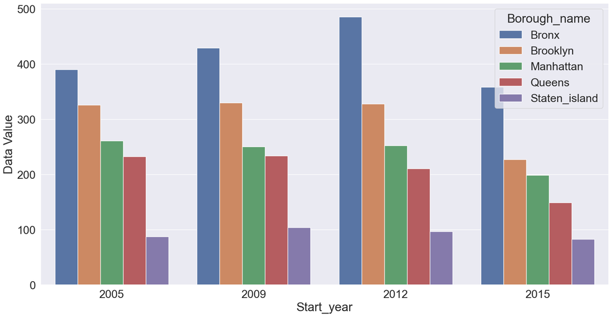

```python
plt.figure(figsize=(20,10))
sns.set(font_scale=2)
sns.barplot(x='Start_year', y='Data Value',hue = "Borough_name",  data=ast)
plt.xticks(rotation=0)
plt.show;
```

# Insight:

This trend of Asthma hospitalizations due to ozone in New York geographical boroughs over the years shows that Bronx inhabitant has the highest number of hospitalization while Staten_Island has the lowest number of hospitalization due to Ozone.

# Cardiac and respiratory deaths due to Ozone

```python
cardiac_death_ozone = annual_avg_impact[annual_avg_impact['Name']=='Cardiac and respiratory deaths due to Ozone']
cardiac_death_ozone.head()
```

|  | Unique ID | Indicator ID | Name | Measure | Measure Info | Geo Type Name | Geo Join ID | Geo Place Name | Time Period | Start_Date | Data Value | Start_year | Borough_name | Pollutant_name |
| --- | --- | --- | --- | --- | --- | --- | --- | --- | --- | --- | --- | --- | --- | --- |
| 4016 | 518704 | 652 | Cardiac and respiratory deaths due to Ozone | Estimated annual rate | per 100,000 | UHF42 | 202 | Downtown - Heights - Slope | 2012-2014 | 2012-01-02 | 4.3 | 2012 | Brooklyn | Pollutant Impacts |
| 4017 | 629165 | 652 | Cardiac and respiratory deaths due to Ozone | Estimated annual rate | per 100,000 | UHF42 | 202 | Downtown - Heights - Slope | 2015-2017 | 2015-01-01 | 3.2 | 2015 | Brooklyn | Pollutant Impacts |
| 4934 | 151423 | 652 | Cardiac and respiratory deaths due to Ozone | Estimated annual rate | per 100,000 | UHF42 | 503 | Willowbrook | 2009-2011 | 2009-01-01 | 9.7 | 2009 | Staten_island | Pollutant Impacts |
| 4935 | 151415 | 652 | Cardiac and respiratory deaths due to Ozone | Estimated annual rate | per 100,000 | UHF42 | 405 | Ridgewood - Forest Hills | 2009-2011 | 2009-01-01 | 5.5 | 2009 | Queens | Pollutant Impacts |
| 5325 | 151401 | 652 | Cardiac and respiratory deaths due to Ozone | Estimated annual rate | per 100,000 | UHF42 | 301 | Washington Heights | 2009-2011 | 2009-01-01 | 3.2 | 2009 | Manhattan | Pollutant Impacts |

```python
card_o = cardiac_death_ozone.groupby(['Name', 'Borough_name','Start_year'])['Data Value'].sum().sort_values(ascending=False).reset_index()
card_o
```

|  | Name | Borough_name | Start_year | Data Value |
| --- | --- | --- | --- | --- |
| 0 | Cardiac and respiratory deaths due to Ozone | Brooklyn | 2005 | 64.4 |
| 1 | Cardiac and respiratory deaths due to Ozone | Brooklyn | 2009 | 60.1 |
| 2 | Cardiac and respiratory deaths due to Ozone | Brooklyn | 2012 | 59.4 |
| 3 | Cardiac and respiratory deaths due to Ozone | Queens | 2005 | 58.4 |
| 4 | Cardiac and respiratory deaths due to Ozone | Queens | 2012 | 57.8 |
| 5 | Cardiac and respiratory deaths due to Ozone | Brooklyn | 2015 | 57.5 |
| 6 | Cardiac and respiratory deaths due to Ozone | Queens | 2015 | 54.7 |
| 7 | Cardiac and respiratory deaths due to Ozone | Queens | 2009 | 53.7 |
| 8 | Cardiac and respiratory deaths due to Ozone | Bronx | 2012 | 47.6 |
| 9 | Cardiac and respiratory deaths due to Ozone | Manhattan | 2012 | 44.3 |
| 10 | Cardiac and respiratory deaths due to Ozone | Bronx | 2015 | 43.6 |
| 11 | Cardiac and respiratory deaths due to Ozone | Manhattan | 2005 | 42.9 |
| 12 | Cardiac and respiratory deaths due to Ozone | Manhattan | 2015 | 42.3 |
| 13 | Cardiac and respiratory deaths due to Ozone | Manhattan | 2009 | 41.3 |
| 14 | Cardiac and respiratory deaths due to Ozone | Bronx | 2009 | 39.9 |
| 15 | Cardiac and respiratory deaths due to Ozone | Bronx | 2005 | 39.5 |
| 16 | Cardiac and respiratory deaths due to Ozone | Staten_island | 2005 | 38.9 |
| 17 | Cardiac and respiratory deaths due to Ozone | Staten_island | 2009 | 38.9 |
| 18 | Cardiac and respiratory deaths due to Ozone | Staten_island | 2012 | 37.4 |
| 19 | Cardiac and respiratory deaths due to Ozone | Staten_island | 2015 | 36.5 |

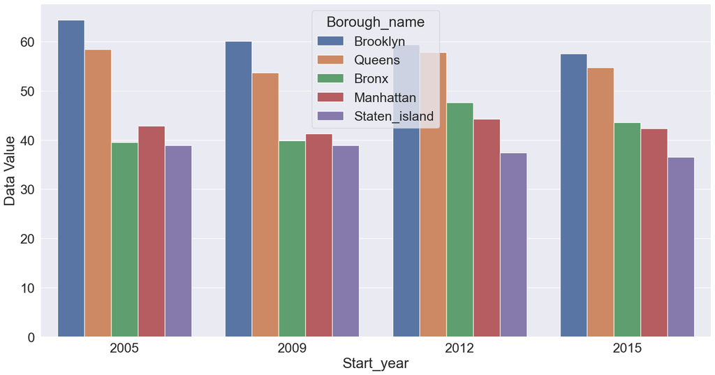

```python
plt.figure(figsize=(20,10))
sns.set(font_scale=2)
sns.barplot(x='Start_year', y='Data Value',hue = "Borough_name",  data=card_o)
plt.xticks(rotation=0)
plt.show;
```

# Insight:

This trend of Cadiac and Respiratory death due to ozone in New York geographical boroughs over the years shows that Brooklyn and Queens inhabitant has the highest number of death rate while Staten_Island has the lowest number of death rate due to cadiac and respiratory due to ozone.

# Cardiovascular hospitalizations due to PM2.5 (age 40+)

```python
cardio_hos_fine_40 = annual_avg_impact[annual_avg_impact['Name']=='Cardiovascular hospitalizations due to PM2.5 (age 40+)']
cardio_hos_fine_40.head()
```

|  | Unique ID | Indicator ID | Name | Measure | Measure Info | Geo Type Name | Geo Join ID | Geo Place Name | Time Period | Start_Date | Data Value | Start_year | Borough_name | Pollutant_name |
| --- | --- | --- | --- | --- | --- | --- | --- | --- | --- | --- | --- | --- | --- | --- |
| 3139 | 628604 | 651 | Cardiovascular hospitalizations due to PM2.5 (... | Estimated annual rate | per 100,000 adults | UHF42 | 306 | Chelsea - Clinton | 2015-2017 | 2015-01-01 | 11.70 | 2015 | Manhattan | Pollutant Impacts |
| 4137 | 518872 | 651 | Cardiovascular hospitalizations due to PM2.5 (... | Estimated annual rate | per 100,000 adults | UHF42 | 405 | Ridgewood - Forest Hills | 2012-2014 | 2012-01-02 | 11.24 | 2012 | Queens | Pollutant Impacts |
| 5350 | 628576 | 651 | Cardiovascular hospitalizations due to PM2.5 (... | Estimated annual rate | per 100,000 adults | Borough | 1 | Bronx | 2015-2017 | 2015-01-01 | 21.00 | 2015 | Bronx | Pollutant Impacts |
| 5351 | 628615 | 651 | Cardiovascular hospitalizations due to PM2.5 (... | Estimated annual rate | per 100,000 adults | UHF42 | 407 | Southwest Queens | 2015-2017 | 2015-01-01 | 18.50 | 2015 | Queens | Pollutant Impacts |
| 5361 | 628605 | 651 | Cardiovascular hospitalizations due to PM2.5 (... | Estimated annual rate | per 100,000 adults | UHF42 | 307 | Gramercy Park - Murray Hill | 2015-2017 | 2015-01-01 | 12.00 | 2015 | Manhattan | Pollutant Impacts |

```python
cardio_hos_fine_40.groupby(['Name', 'Borough_name'])['Data Value'].sum().sort_values(ascending=False)
```

```
Name                                                    Borough_name
Cardiovascular hospitalizations due to PM2.5 (age 40+)  Brooklyn         990.56
                                                        Bronx            787.00
                                                        Manhattan        714.69
                                                        Queens           710.63
                                                        Staten_island    359.66
Name: Data Value, dtype: float64
```

```python
cardio_fine_40 = cardio_hos_fine_40.groupby(['Name', 'Borough_name','Start_year'])['Data Value'].sum().sort_values(ascending=False).reset_index()
cardio_fine_40
```

|  | Name | Borough_name | Start_year | Data Value |
| --- | --- | --- | --- | --- |
| 0 | Cardiovascular hospitalizations due to PM2.5 (... | Brooklyn | 2005 | 351.50 |
| 1 | Cardiovascular hospitalizations due to PM2.5 (... | Bronx | 2005 | 281.20 |
| 2 | Cardiovascular hospitalizations due to PM2.5 (... | Manhattan | 2005 | 251.50 |
| 3 | Cardiovascular hospitalizations due to PM2.5 (... | Brooklyn | 2009 | 246.70 |
| 4 | Cardiovascular hospitalizations due to PM2.5 (... | Queens | 2005 | 243.40 |
| 5 | Cardiovascular hospitalizations due to PM2.5 (... | Brooklyn | 2015 | 213.90 |
| 6 | Cardiovascular hospitalizations due to PM2.5 (... | Bronx | 2015 | 186.20 |
| 7 | Cardiovascular hospitalizations due to PM2.5 (... | Bronx | 2009 | 179.90 |
| 8 | Cardiovascular hospitalizations due to PM2.5 (... | Brooklyn | 2012 | 178.46 |
| 9 | Cardiovascular hospitalizations due to PM2.5 (... | Queens | 2009 | 174.90 |
| 10 | Cardiovascular hospitalizations due to PM2.5 (... | Queens | 2015 | 169.80 |
| 11 | Cardiovascular hospitalizations due to PM2.5 (... | Manhattan | 2009 | 165.90 |
| 12 | Cardiovascular hospitalizations due to PM2.5 (... | Manhattan | 2015 | 159.20 |
| 13 | Cardiovascular hospitalizations due to PM2.5 (... | Bronx | 2012 | 139.70 |
| 14 | Cardiovascular hospitalizations due to PM2.5 (... | Manhattan | 2012 | 138.09 |
| 15 | Cardiovascular hospitalizations due to PM2.5 (... | Staten_island | 2005 | 127.60 |
| 16 | Cardiovascular hospitalizations due to PM2.5 (... | Queens | 2012 | 122.53 |
| 17 | Cardiovascular hospitalizations due to PM2.5 (... | Staten_island | 2015 | 86.40 |
| 18 | Cardiovascular hospitalizations due to PM2.5 (... | Staten_island | 2009 | 82.60 |
| 19 | Cardiovascular hospitalizations due to PM2.5 (... | Staten_island | 2012 | 63.06 |

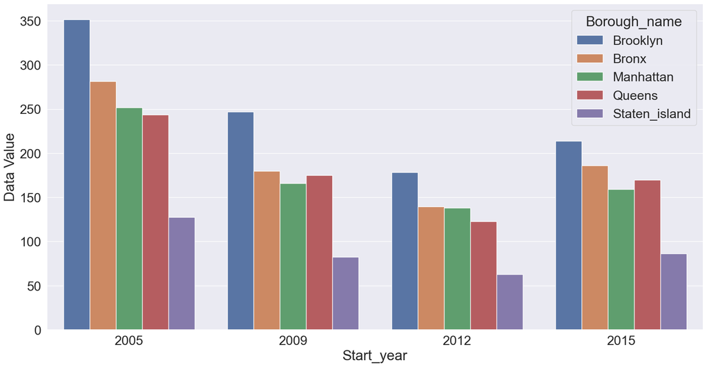

```python
plt.figure(figsize=(20,10))
sns.set(font_scale=2)
sns.barplot(x='Start_year', y='Data Value',hue = "Borough_name",  data=cardio_fine_40)
plt.xticks(rotation=0)
plt.show;
```

# Insight:

This chart of Cadiovascular hospitalization due to PM2.5 in New York geographical boroughs over the years shows that Brooklyn inhabitants has the highest number of hospitalization while Staten_Island has the lowest number of cardiovascular hospitalization due to PM2.5.

# Respiratory hospitalizations due to PM2.5 (age 20+)

```python
cardio_hos_fine_20 = annual_avg_impact[annual_avg_impact['Name']=='Respiratory hospitalizations due to PM2.5 (age 20+)']
cardio_hos_fine_20.head()
```

|  | Unique ID | Indicator ID | Name | Measure | Measure Info | Geo Type Name | Geo Join ID | Geo Place Name | Time Period | Start_Date | Data Value | Start_year | Borough_name | Pollutant_name |
| --- | --- | --- | --- | --- | --- | --- | --- | --- | --- | --- | --- | --- | --- | --- |
| 1160 | 131539 | 650 | Respiratory hospitalizations due to PM2.5 (age... | Estimated annual rate | per 100,000 adults | UHF42 | 405 | Ridgewood - Forest Hills | 2009-2011 | 2009-01-01 | 12.40 | 2009 | Queens | Pollutant Impacts |
| 1161 | 628535 | 650 | Respiratory hospitalizations due to PM2.5 (age... | Estimated annual rate | per 100,000 adults | UHF42 | 103 | Fordham - Bronx Pk | 2015-2017 | 2015-01-01 | 19.40 | 2015 | Bronx | Pollutant Impacts |
| 1162 | 518796 | 650 | Respiratory hospitalizations due to PM2.5 (age... | Estimated annual rate | per 100,000 adults | UHF42 | 105 | Crotona -Tremont | 2012-2014 | 2012-01-02 | 20.75 | 2012 | Bronx | Pollutant Impacts |
| 1163 | 518814 | 650 | Respiratory hospitalizations due to PM2.5 (age... | Estimated annual rate | per 100,000 adults | UHF42 | 305 | Upper East Side | 2012-2014 | 2012-01-02 | 8.38 | 2012 | Manhattan | Pollutant Impacts |
| 1164 | 628555 | 650 | Respiratory hospitalizations due to PM2.5 (age... | Estimated annual rate | per 100,000 adults | UHF42 | 305 | Upper East Side | 2015-2017 | 2015-01-01 | 6.70 | 2015 | Manhattan | Pollutant Impacts |

```python
cardio_fine_20 = cardio_hos_fine_20.groupby(['Name', 'Borough_name','Start_year'])['Data Value'].sum().sort_values(ascending=False).reset_index()
cardio_fine_20
```

|  | Name | Borough_name | Start_year | Data Value |
| --- | --- | --- | --- | --- |
| 0 | Respiratory hospitalizations due to PM2.5 (age... | Bronx | 2005 | 274.40 |
| 1 | Respiratory hospitalizations due to PM2.5 (age... | Brooklyn | 2005 | 237.00 |
| 2 | Respiratory hospitalizations due to PM2.5 (age... | Manhattan | 2005 | 210.70 |
| 3 | Respiratory hospitalizations due to PM2.5 (age... | Bronx | 2009 | 195.00 |
| 4 | Respiratory hospitalizations due to PM2.5 (age... | Queens | 2005 | 183.70 |
| 5 | Respiratory hospitalizations due to PM2.5 (age... | Bronx | 2015 | 170.60 |
| 6 | Respiratory hospitalizations due to PM2.5 (age... | Bronx | 2012 | 158.42 |
| 7 | Respiratory hospitalizations due to PM2.5 (age... | Brooklyn | 2009 | 157.90 |
| 8 | Respiratory hospitalizations due to PM2.5 (age... | Manhattan | 2009 | 138.20 |
| 9 | Respiratory hospitalizations due to PM2.5 (age... | Brooklyn | 2012 | 136.70 |
| 10 | Respiratory hospitalizations due to PM2.5 (age... | Queens | 2009 | 128.90 |
| 11 | Respiratory hospitalizations due to PM2.5 (age... | Brooklyn | 2015 | 122.90 |
| 12 | Respiratory hospitalizations due to PM2.5 (age... | Manhattan | 2012 | 120.29 |
| 13 | Respiratory hospitalizations due to PM2.5 (age... | Queens | 2015 | 109.00 |
| 14 | Respiratory hospitalizations due to PM2.5 (age... | Manhattan | 2015 | 106.10 |
| 15 | Respiratory hospitalizations due to PM2.5 (age... | Queens | 2012 | 95.70 |
| 16 | Respiratory hospitalizations due to PM2.5 (age... | Staten_island | 2005 | 89.20 |
| 17 | Respiratory hospitalizations due to PM2.5 (age... | Staten_island | 2015 | 77.00 |
| 18 | Respiratory hospitalizations due to PM2.5 (age... | Staten_island | 2009 | 73.30 |
| 19 | Respiratory hospitalizations due to PM2.5 (age... | Staten_island | 2012 | 69.10 |

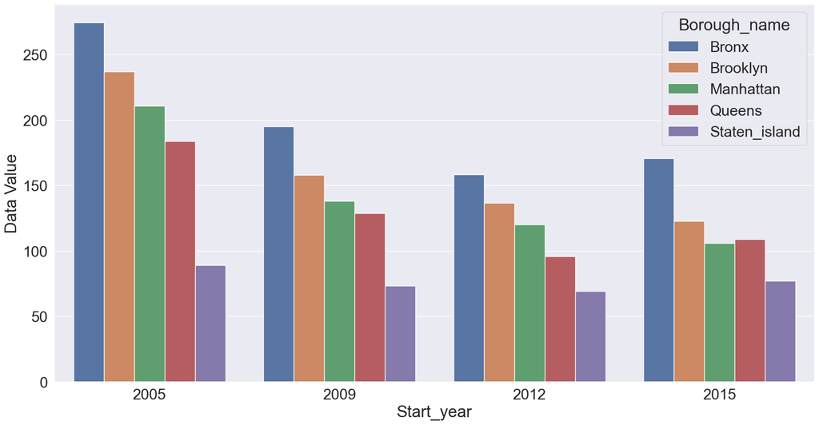

```python
plt.figure(figsize=(20,10))
sns.set(font_scale=2)
sns.barplot(x='Start_year', y='Data Value',hue = "Borough_name",  data=cardio_fine_20)
plt.xticks(rotation=0)
plt.show;
```

# Insight:

# Deaths due to PM2.5

```python
death_fine = annual_avg_impact[annual_avg_impact['Name']=='Deaths due to PM2.5']
death_fine.head()
```

|  | Unique ID | Indicator ID | Name | Measure | Measure Info | Geo Type Name | Geo Join ID | Geo Place Name | Time Period | Start_Date | Data Value | Start_year | Borough_name | Pollutant_name |
| --- | --- | --- | --- | --- | --- | --- | --- | --- | --- | --- | --- | --- | --- | --- |
| 7776 | 131573 | 639 | Deaths due to PM2.5 | Estimated annual rate (age 30+) | per 100,000 adults | UHF42 | 301 | Washington Heights | 2009-2011 | 2009-01-01 | 46.00 | 2009 | Manhattan | Pollutant Impacts |
| 7777 | 131562 | 639 | Deaths due to PM2.5 | Estimated annual rate (age 30+) | per 100,000 adults | UHF42 | 201 | Greenpoint | 2009-2011 | 2009-01-01 | 45.60 | 2009 | Brooklyn | Pollutant Impacts |
| 7778 | 131555 | 639 | Deaths due to PM2.5 | Estimated annual rate (age 30+) | per 100,000 adults | UHF42 | 101 | Kingsbridge - Riverdale | 2009-2011 | 2009-01-01 | 77.60 | 2009 | Bronx | Pollutant Impacts |
| 7779 | 628407 | 639 | Deaths due to PM2.5 | Estimated annual rate (age 30+) | per 100,000 adults | UHF42 | 301 | Washington Heights | 2015-2017 | 2015-01-01 | 33.20 | 2015 | Manhattan | Pollutant Impacts |
| 7780 | 518782 | 639 | Deaths due to PM2.5 | Estimated annual rate (age 30+) | per 100,000 adults | UHF42 | 501 | Port Richmond | 2012-2014 | 2012-01-02 | 41.11 | 2012 | Staten_island | Pollutant Impacts |

```python
death_fine_grp = death_fine.groupby(['Name', 'Borough_name','Start_year'])['Data Value'].sum().sort_values(ascending=False).reset_index()
death_fine_grp
```

|  | Name | Borough_name | Start_year | Data Value |
| --- | --- | --- | --- | --- |
| 0 | Deaths due to PM2.5 | Brooklyn | 2005 | 797.10 |
| 1 | Deaths due to PM2.5 | Manhattan | 2005 | 727.00 |
| 2 | Deaths due to PM2.5 | Bronx | 2005 | 698.70 |
| 3 | Deaths due to PM2.5 | Queens | 2005 | 633.40 |
| 4 | Deaths due to PM2.5 | Brooklyn | 2009 | 586.90 |
| 5 | Deaths due to PM2.5 | Manhattan | 2009 | 547.50 |
| 6 | Deaths due to PM2.5 | Bronx | 2009 | 503.90 |
| 7 | Deaths due to PM2.5 | Manhattan | 2012 | 480.13 |
| 8 | Deaths due to PM2.5 | Brooklyn | 2012 | 479.96 |
| 9 | Deaths due to PM2.5 | Queens | 2009 | 464.70 |
| 10 | Deaths due to PM2.5 | Brooklyn | 2015 | 445.30 |
| 11 | Deaths due to PM2.5 | Bronx | 2012 | 430.79 |
| 12 | Deaths due to PM2.5 | Manhattan | 2015 | 412.00 |
| 13 | Deaths due to PM2.5 | Bronx | 2015 | 403.40 |
| 14 | Deaths due to PM2.5 | Queens | 2012 | 372.44 |
| 15 | Deaths due to PM2.5 | Queens | 2015 | 356.90 |
| 16 | Deaths due to PM2.5 | Staten_island | 2005 | 355.40 |
| 17 | Deaths due to PM2.5 | Staten_island | 2009 | 261.40 |
| 18 | Deaths due to PM2.5 | Staten_island | 2012 | 240.35 |
| 19 | Deaths due to PM2.5 | Staten_island | 2015 | 233.10 |

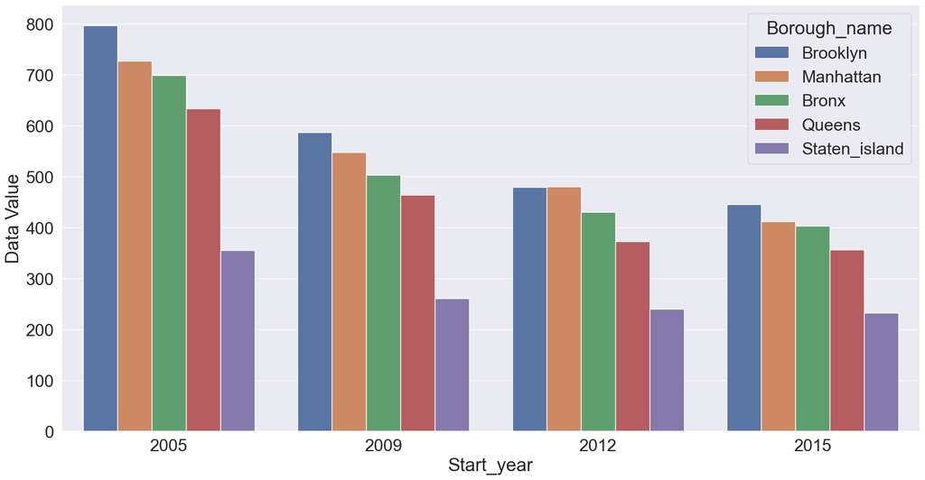

```python
plt.figure(figsize=(20,10))
sns.set(font_scale=2)
sns.barplot(x='Start_year', y='Data Value',hue = "Borough_name",  data=death_fine_grp)
plt.xticks(rotation=0)
plt.show;
```

# Insight:

This chart of death due to PM2.5 in New York geographical boroughs over the years shows that Brooklyn inhabitants has the highest number of death while Staten_Island has the lowest number of death due to PM2.5.

# Factors that contribute pollutants

across time

```python
factors = ['Boiler Emissions- Total SO2 Emissions',
'Boiler Emissions- Total PM2.5 Emissions',
'Boiler Emissions- Total NOx Emissions',
'Annual vehicle miles travelled (cars)',
'Annual vehicle miles travelled (trucks)']

annual_avg_factor = annual_avg[annual_avg['Name'].isin(factors)]
annual_avg_factor
```

|  | Unique ID | Indicator ID | Name | Measure | Measure Info | Geo Type Name | Geo Join ID | Geo Place Name | Time Period | Start_Date | Data Value | Start_year | Borough_name | Pollutant_name |
| --- | --- | --- | --- | --- | --- | --- | --- | --- | --- | --- | --- | --- | --- | --- |
| 1625 | 179789 | 640 | Boiler Emissions- Total SO2 Emissions | Number per km2 | number | UHF42 | 202 | Downtown - Heights - Slope | 2015 | 2015-01-01 | 1.2 | 2015 | Brooklyn | Pollutant Impacts |
| 1739 | 130443 | 640 | Boiler Emissions- Total SO2 Emissions | Number per km2 | number | Borough | 4 | Queens | 2013 | 2013-01-01 | 2.2 | 2013 | Queens | Pollutant Impacts |
| 1752 | 179793 | 640 | Boiler Emissions- Total SO2 Emissions | Number per km2 | number | UHF42 | 107 | Hunts Point - Mott Haven | 2015 | 2015-01-01 | 1.7 | 2015 | Bronx | Pollutant Impacts |
| 1778 | 179807 | 640 | Boiler Emissions- Total SO2 Emissions | Number per km2 | number | UHF42 | 307 | Gramercy Park - Murray Hill | 2015 | 2015-01-01 | 41.5 | 2015 | Manhattan | Pollutant Impacts |
| 1785 | 179792 | 640 | Boiler Emissions- Total SO2 Emissions | Number per km2 | number | UHF42 | 206 | Borough Park | 2015 | 2015-01-01 | 1.1 | 2015 | Brooklyn | Pollutant Impacts |
| ... | ... | ... | ... | ... | ... | ... | ... | ... | ... | ... | ... | ... | ... | ... |
| 15928 | 325101 | 645 | Annual vehicle miles travelled (trucks) | million miles | per km2 | UHF42 | 204 | East New York | 2016 | 2016-01-01 | 0.8 | 2016 | Brooklyn | Pollutant Impacts |
| 16060 | 179783 | 640 | Boiler Emissions- Total SO2 Emissions | Number per km2 | number | UHF42 | 104 | Pelham - Throgs Neck | 2015 | 2015-01-01 | 2.8 | 2015 | Bronx | Pollutant Impacts |
| 16061 | 179813 | 640 | Boiler Emissions- Total SO2 Emissions | Number per km2 | number | Borough | 5 | Staten Island | 2015 | 2015-01-01 | 0.1 | 2015 | Staten_island | Pollutant Impacts |
| 16063 | 130400 | 640 | Boiler Emissions- Total SO2 Emissions | Number per km2 | number | UHF42 | 104 | Pelham - Throgs Neck | 2013 | 2013-01-01 | 4.4 | 2013 | Bronx | Pollutant Impacts |
| 16077 | 130444 | 640 | Boiler Emissions- Total SO2 Emissions | Number per km2 | number | Borough | 5 | Staten Island | 2013 | 2013-01-01 | 0.1 | 2013 | Staten_island | Pollutant Impacts |

711 rows × 14 columns

```python
annual_avg_factor['Name'].value_counts()
```

```
Name
Annual vehicle miles travelled (cars)      214
Annual vehicle miles travelled (trucks)    209
Boiler Emissions- Total SO2 Emissions       96
Boiler Emissions- Total PM2.5 Emissions     96
Boiler Emissions- Total NOx Emissions       96
Name: count, dtype: int64
```

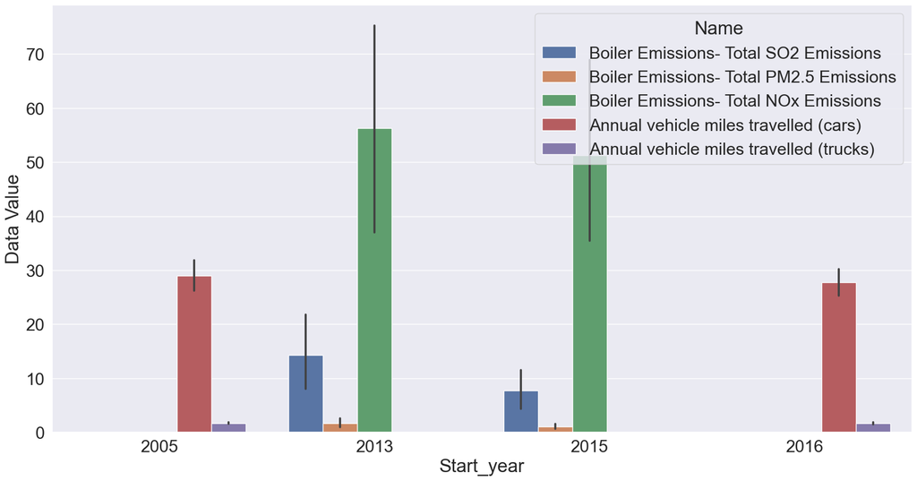

```python
plt.figure(figsize=(20,10))
sns.set(font_scale=2)
sns.barplot(x='Start_year', y='Data Value',hue = "Name",  data=annual_avg_factor)
plt.xticks(rotation=0)
plt.show;
```

# Insight:

# pollution factors across boroughs

Boiler Emissions- Total SO2 Emissions

```python
boiler_so2 = annual_avg_factor[annual_avg_factor['Name']=='Boiler Emissions- Total SO2 Emissions']
boiler_so2.head()
```

|  | Unique ID | Indicator ID | Name | Measure | Measure Info | Geo Type Name | Geo Join ID | Geo Place Name | Time Period | Start_Date | Data Value | Start_year | Borough_name | Pollutant_name |
| --- | --- | --- | --- | --- | --- | --- | --- | --- | --- | --- | --- | --- | --- | --- |
| 1625 | 179789 | 640 | Boiler Emissions- Total SO2 Emissions | Number per km2 | number | UHF42 | 202 | Downtown - Heights - Slope | 2015 | 2015-01-01 | 1.2 | 2015 | Brooklyn | Pollutant Impacts |
| 1739 | 130443 | 640 | Boiler Emissions- Total SO2 Emissions | Number per km2 | number | Borough | 4 | Queens | 2013 | 2013-01-01 | 2.2 | 2013 | Queens | Pollutant Impacts |
| 1752 | 179793 | 640 | Boiler Emissions- Total SO2 Emissions | Number per km2 | number | UHF42 | 107 | Hunts Point - Mott Haven | 2015 | 2015-01-01 | 1.7 | 2015 | Bronx | Pollutant Impacts |
| 1778 | 179807 | 640 | Boiler Emissions- Total SO2 Emissions | Number per km2 | number | UHF42 | 307 | Gramercy Park - Murray Hill | 2015 | 2015-01-01 | 41.5 | 2015 | Manhattan | Pollutant Impacts |
| 1785 | 179792 | 640 | Boiler Emissions- Total SO2 Emissions | Number per km2 | number | UHF42 | 206 | Borough Park | 2015 | 2015-01-01 | 1.1 | 2015 | Brooklyn | Pollutant Impacts |

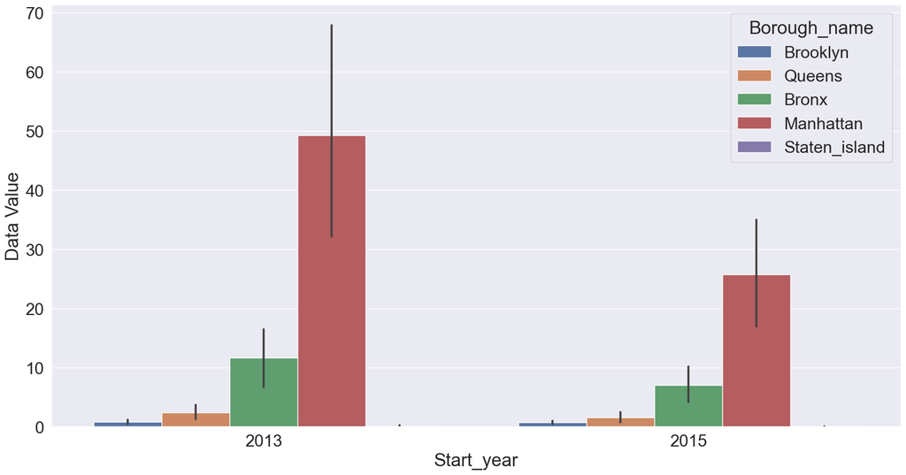

```python
plt.figure(figsize=(20,10))
sns.set(font_scale=2)
sns.barplot(x='Start_year', y='Data Value',hue = "Borough_name",  data=boiler_so2)
plt.xticks(rotation=0)
plt.show;
```

# Insight:

This chart shows that Manhattan has the highest rate of SO2 emmision

# Boiler Emissions- Total PM2.5 Emissions

```python
boiler_fine = annual_avg_factor[annual_avg_factor['Name']=='Boiler Emissions- Total PM2.5 Emissions']
boiler_fine.head()
```

|  | Unique ID | Indicator ID | Name | Measure | Measure Info | Geo Type Name | Geo Join ID | Geo Place Name | Time Period | Start_Date | Data Value | Start_year | Borough_name | Pollutant_name |
| --- | --- | --- | --- | --- | --- | --- | --- | --- | --- | --- | --- | --- | --- | --- |
| 3325 | 179825 | 641 | Boiler Emissions- Total PM2.5 Emissions | Number per km2 | number | UHF42 | 406 | Fresh Meadows | 2015 | 2015-01-01 | 0.4 | 2015 | Queens | Pollutant Impacts |
| 3327 | 179852 | 641 | Boiler Emissions- Total PM2.5 Emissions | Number per km2 | number | UHF42 | 306 | Chelsea - Clinton | 2015 | 2015-01-01 | 4.9 | 2015 | Manhattan | Pollutant Impacts |
| 3328 | 179839 | 641 | Boiler Emissions- Total PM2.5 Emissions | Number per km2 | number | UHF42 | 102 | Northeast Bronx | 2015 | 2015-01-01 | 0.3 | 2015 | Bronx | Pollutant Impacts |
| 4417 | 179829 | 641 | Boiler Emissions- Total PM2.5 Emissions | Number per km2 | number | UHF42 | 405 | Ridgewood - Forest Hills | 2015 | 2015-01-01 | 0.2 | 2015 | Queens | Pollutant Impacts |
| 4938 | 179828 | 641 | Boiler Emissions- Total PM2.5 Emissions | Number per km2 | number | UHF42 | 201 | Greenpoint | 2015 | 2015-01-01 | 0.0 | 2015 | Brooklyn | Pollutant Impacts |

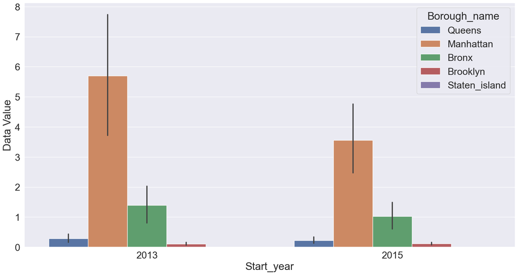

```python
plt.figure(figsize=(20,10))
sns.set(font_scale=2)
sns.barplot(x='Start_year', y='Data Value', hue='Borough_name', data=boiler_fine)
plt.xticks(rotation=0)
plt.show;
```

# Insight:

# Boiler Emissions- Total NOx Emissions

```python
boiler_nox = annual_avg_factor[annual_avg_factor['Name']=='Boiler Emissions- Total NOx Emissions']
boiler_nox.head()
```

|  | Unique ID | Indicator ID | Name | Measure | Measure Info | Geo Type Name | Geo Join ID | Geo Place Name | Time Period | Start_Date | Data Value | Start_year | Borough_name | Pollutant_name |
| --- | --- | --- | --- | --- | --- | --- | --- | --- | --- | --- | --- | --- | --- | --- |
| 3326 | 179729 | 642 | Boiler Emissions- Total NOx Emissions | Number per km2 | number | UHF42 | 406 | Fresh Meadows | 2015 | 2015-01-01 | 14.3 | 2015 | Queens | Pollutant Impacts |
| 4416 | 179733 | 642 | Boiler Emissions- Total NOx Emissions | Number per km2 | number | UHF42 | 405 | Ridgewood - Forest Hills | 2015 | 2015-01-01 | 22.5 | 2015 | Queens | Pollutant Impacts |
| 4418 | 179749 | 642 | Boiler Emissions- Total NOx Emissions | Number per km2 | number | UHF42 | 103 | Fordham - Bronx Pk | 2015 | 2015-01-01 | 65.0 | 2015 | Bronx | Pollutant Impacts |
| 4937 | 179732 | 642 | Boiler Emissions- Total NOx Emissions | Number per km2 | number | UHF42 | 201 | Greenpoint | 2015 | 2015-01-01 | 18.8 | 2015 | Brooklyn | Pollutant Impacts |
| 5559 | 179763 | 642 | Boiler Emissions- Total NOx Emissions | Number per km2 | number | Borough | 1 | Bronx | 2015 | 2015-01-01 | 39.5 | 2015 | Bronx | Pollutant Impacts |

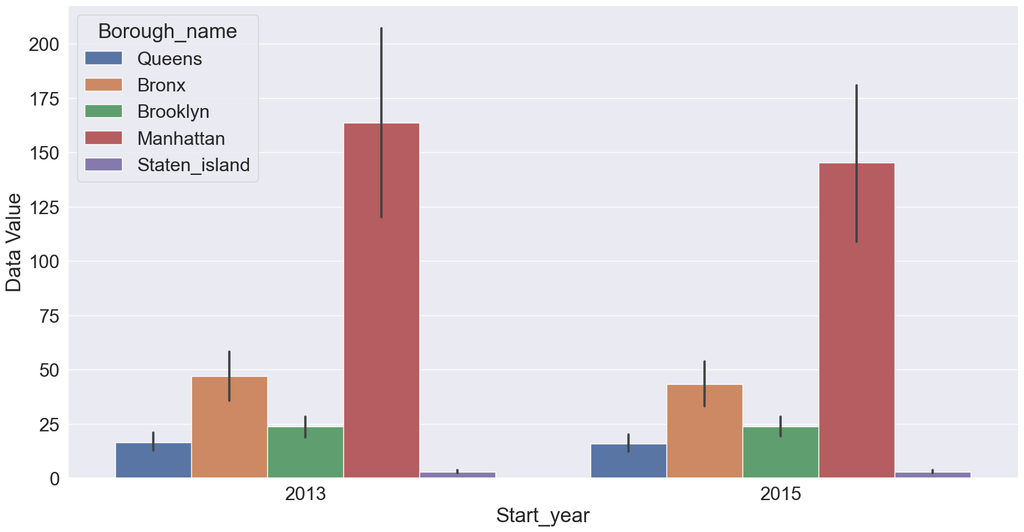

```python
plt.figure(figsize=(20,10))
sns.set(font_scale=2)
sns.barplot(x='Start_year', y='Data Value', hue='Borough_name', data=boiler_nox)
plt.xticks(rotation=0)
plt.show;
```

# Insights:

This chart shows that Manhattan borough has the highest rate of NO2 emisions while Staten_Island has the lowest rate.

# Correlations

```python
df.describe()
```

|  | Unique ID | Indicator ID | Geo Join ID | Start_Date | Data Value | Start_year |
| --- | --- | --- | --- | --- | --- | --- |
| count | 16218.000000 | 16218.000000 | 1.621800e+04 | 16218 | 16218.000000 | 16218.000000 |
| mean | 372730.417746 | 427.803613 | 6.097103e+05 | 2014-03-12 17:12:32.497225472 | 19.975917 | 2013.730115 |
| min | 121644.000000 | 365.000000 | 1.000000e+00 | 2005-01-01 00:00:00 | 0.000000 | 2005.000000 |
| 25% | 173211.250000 | 365.000000 | 2.020000e+02 | 2011-01-01 00:00:00 | 9.050000 | 2011.000000 |
| 50% | 325262.500000 | 375.000000 | 3.030000e+02 | 2014-06-01 00:00:00 | 15.300000 | 2014.000000 |
| 75% | 605270.750000 | 386.000000 | 4.040000e+02 | 2017-06-01 00:00:00 | 26.037500 | 2017.000000 |
| max | 799868.000000 | 661.000000 | 1.051061e+08 | 2021-06-01 00:00:00 | 424.700000 | 2021.000000 |
| std | 215507.613560 | 110.921411 | 7.893388e+06 | NaN | 21.322349 | 4.230179 |

```python
#Correlation matrix for Data Value and Geo Join ID
corr1 =df[['Data Value', 'Geo Join ID']].corr()
corr1
```

|  | Data Value | Geo Join ID |
| --- | --- | --- |
| Data Value | 1.000000 | -0.006778 |
| Geo Join ID | -0.006778 | 1.000000 |

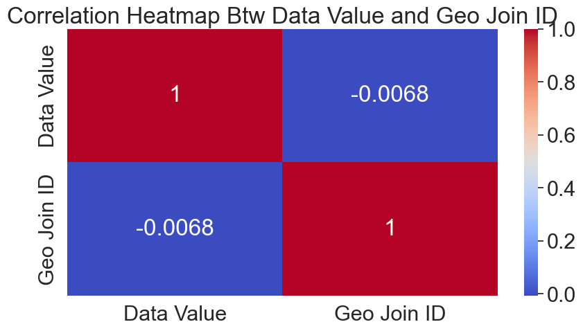

```python
plt.figure(figsize=(10, 5))
sns.heatmap(corr1,
           annot=True,
           cmap='coolwarm')
plt.title("Correlation Heatmap Btw Data Value and Geo Join ID")
plt.show()
```

# Insight:

This chart shows that there is no correlation between data values and geo join ID

```python
#Correlation matrix for Data Value and Indicator ID
corr2 =df[['Data Value', 'Indicator ID']].corr()
corr2
```

|  | Data Value | Indicator ID |
| --- | --- | --- |
| Data Value | 1.000000 | 0.258522 |
| Indicator ID | 0.258522 | 1.000000 |

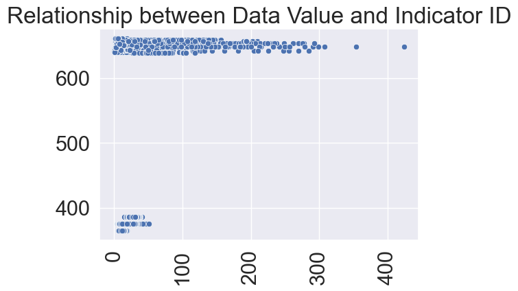

```python
#To create scatter plot showing correlation between Survival rate and Age
plt.figure(figsize=(6,4))
sns.scatterplot(x='Data Value', y='Indicator ID', data=df)
plt.title('Relationship between Data Value and Indicator ID')
plt.xlabel('')
plt.xticks(rotation = 90)
plt.ylabel('')

plt.show()
```

# Insight:

This chart shows that there is a little correlation between data value of pollutants and indicator ID of pollutants